# PandemicLP

```r
library(PandemicLP)
```

In this vignette, we present the main functionality of the PandemicLP package. The package uses the theory presented in http://est.ufmg.br/covidlp/home/pt/. As the model evolves, new versions of the package are released. This vignette, however, aims to only show the five basic functions of the package.

## Loading data

Function `load_covid()` loads data from online repositories. The first argument is a string with the country’s name. Use `country_list()` for a complete list of possibilities. The second argument is another string with the state’s name *if* the country is “Brazil”. Use `state_list()` for a similar list. Finally, you can use the last_date argument if you don’t want to use all the data and compare the predictions with the data.

```r
MGdata = load_covid("Brazil","MG")
```

## Estimating model

The model is estimated with function `pandemic_model`. It currently uses rstan to draw samples from the posterior distribution. The first argument can be either the output of the `load_covid()` function or a list with the proper elements. Customized control of the stan algorithm can be also set in this function. You can choose to fit the ‘confirmed’ or ‘deaths’ series. Use the option `covidLPconfig = TRUE` to use the same configuration of the app in https://dest-ufmg.shinyapps.io/app_COVID19/.

```r
MGestimated = pandemic_model(MGdata, case_type = "deaths", covidLPconfig = TRUE)
```

By calling the output of the function, a small summary of the estimation is given.

```r
MGestimated
```

```
#> pandemic_model
#>  Distribution:  poisson
#>  Model:         static generalized logistic (d=0)
#>  Type of Case:  deaths
#>  Location:      Brazil_MG
#>  0bservations:  167
#>
#> ------
#> Parameters:
#>    mean se_mean    sd  2.5%   50% 97.5%   n_eff  Rhat
#> a 2.347   0.063 1.453 1.014 2.056 5.158 528.275 0.999
#> b 0.067   0.005 0.081 0.002 0.032 0.289 281.767 0.999
#> c 0.023   0.001 0.007 0.013 0.022 0.039 172.136 0.999
#> f 3.162   0.106 1.636 1.205 2.676 7.241 237.050 0.999
#>
#> Fitted values:
#>         mean    sd  2.5%   50% 97.5%
#> mu[1]  0.101 0.034 0.045 0.098 0.174
#> mu[2]  0.107 0.036 0.049 0.104 0.182
#> mu[3]  0.113 0.037 0.052 0.110 0.190
#>            ...   ...    ...    ...    ...
#> mu[165] 86.250 2.926 80.426 86.320 91.766
#> mu[166] 87.396 3.171 80.939 87.457 93.352
#> mu[167] 88.516 3.436 81.568 88.615 94.992
#>
#> ------
#>
#>  covidLPconfig =  TRUE :
#>
#>  warmup:                                   2000
#>  thin:                                     3
#>  sample_size:                              1000
#>  chains:                                   1
#>  maximum cumulative total number of cases: 0.02 *population
#>  init (chain_id = 1):
#> $a
#> [1] 100
#>
#> $c
#> [1] 0.5
```

[output cut: 10 more lines]

```
#> Priors:
#>
#>  a  ~  Gamma(0.1, 0.1)
#>  b  ~  LogNormal(0, 20)
#>  c  ~  Gamma(2, 9)
#>  f  ~  Gamma(0.01, 0.01)
#>
#>  restrictions:
#>  1:  a/b^f < 0.02 *population
#>  2:  f > 1
#>
#> ------
#> *For help interpreting the printed output see ?print.pandemicEstimated
#> *For more information see ?`summary,stanfit-method`
#> *For details on the model, priors and restrictions, see the Details section in ?pandemic_model
```

Convergence diagnostics can be used on the ‘fit’ element of the output. In particular, the relevant parameters are ‘a’, ‘b’, ‘c’ and ‘f’.

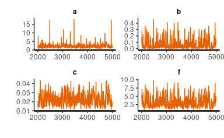

```r
traceplot(MGestimated)+theme(legend.position = "")
```

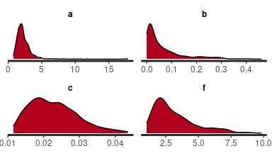

```r
rstan::stan_dens(MGestimated$fit,pars=c("a","b","c","f"))
```

Note: `traceplot` can be used directly on the output, without a reference to the ‘fit’ element nor the parameters.

## Prediction

In order to make the predictions using the model fitted from `pandemic_model`, use the `rstantools::posterior_predict` generic function. Also, set custom prediction horizons with options `horizonLong` and `horizonShort`. The difference is that the long term prediction uses daily predictions and the short term uses accumulated predictions.

```r
MGpredicted = posterior_predict(MGestimated,horizonLong=200)
MGpredicted
```

```
#>
#> Predicted pandemic  for . Can be plotted with plot().
#>
#> Showing predictive median for the long term predictions for .
#>
#> 2020-08-10 2020-08-11 2020-08-12
#>       89.0       90.5       92.0
#>    ...
#>
#> 2021-02-23 2021-02-24 2021-02-25
#>        8.0        8.5        8.0
#>
#> *For customized view, see help(print.pandemicPredicted)
#> **For more details, see help(pandemicPredicted-objects)
```

The output can also be printed for a small summary. Note that the full predictive distribution sample is returned in this function.

## Useful statistics

Some useful statistics from the [CovidLP](http://est.ufmg.br/covidlp/home/pt/) app have been programmed into a function. Use this function to obtain short and long term predictions, predicted total number of cases, predicted peak date and the date when the pandemic is predicted to end.

```r
pandemic_stats(MGpredicted)
```

```
#> $data
#> $data$data
#>           date  cases deaths new_cases new_deaths
#> 1   2020-02-25      0      0         0          0
#> 2   2020-02-26      0      0         0          0
#> 3   2020-02-27      0      0         0          0
#> 4   2020-02-28      0      0         0          0
#> 5   2020-02-29      0      0         0          0
#> 6   2020-03-01      0      0         0          0
#> 7   2020-03-02      0      0         0          0
#> 8   2020-03-03      0      0         0          0
#> 9   2020-03-04      0      0         0          0
#> 10  2020-03-05      0      0         0          0
#> 11  2020-03-06      0      0         0          0
#> 12  2020-03-07      0      0         0          0
```

[output cut: 784 more lines]

## Plotting

Generic function `plot` can be used on the prediction to plot the predictions using the `plotly` package, whose figure is interactive. Two plots are outputted, which can be stored for later use.

```r
MGplots = plot(MGpredicted)
```

```
#> Plotting death cases
#> Long term plot created successfully
#> Short term plot created successfully
#> The generated plots can be stored in a variable.
#> Long term plot: variable$long
#> Short term plot: variable$short
```

```r
MGplots$long
```

[interactive chart not shown]

```r
MGplots$short
```

[interactive chart not shown]